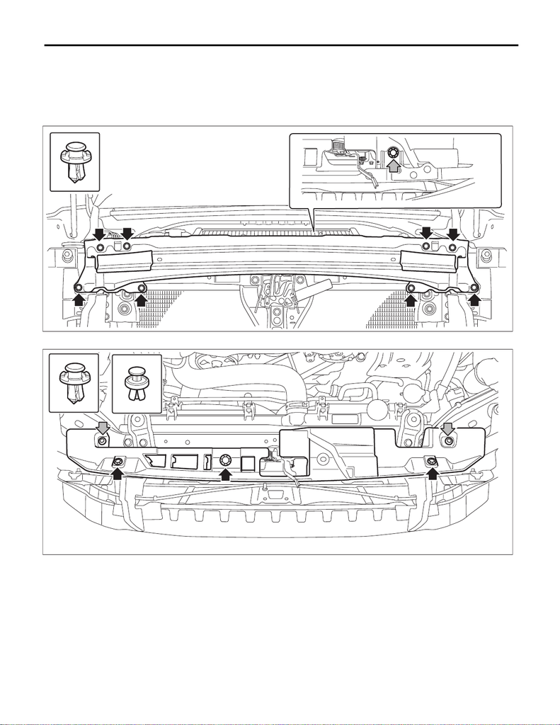

SL-51

Front Hood Lock Assembly

SECURITY AND LOCKS

16.Front Hood Lock Assembly

A: REMOVAL

1) Open the front hood.

2) Remove the bumper face - front. <Ref. to EI-30, REMOVAL, Front Bumper.>

3) Remove the bolts and clips, and remove the energy absorber plate - front.

4) Remove the clips, and remove the cover UPR - front.

SL-02866

SL-02867

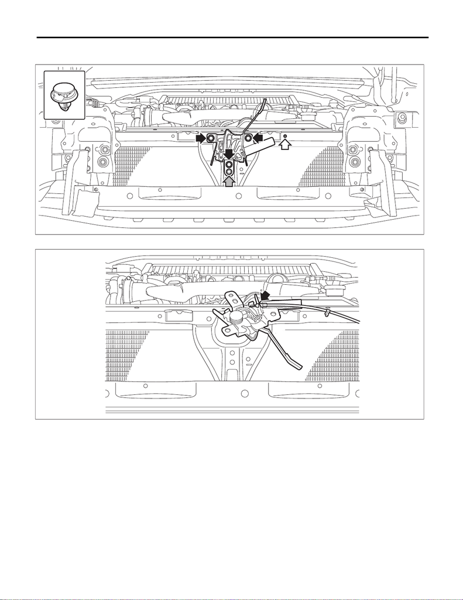

SL-52

Front Hood Lock Assembly

SECURITY AND LOCKS

5) Remove the lock assembly - front hood.

NOTE:

When disconnecting the release cable, refer to “FRONT HOOD OPENER” of “Remote Openers”. <Ref. to

SL-56, FRONT HOOD OPENER, REMOVAL, Remote Openers.>

SL-02868

SL-02869

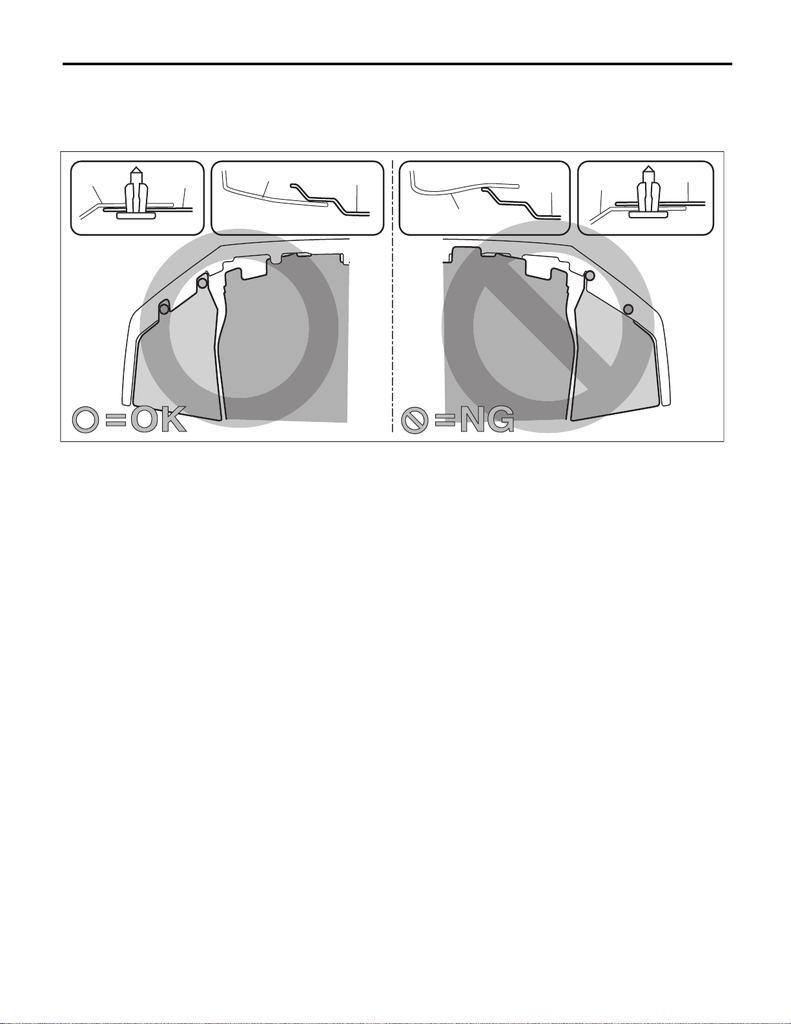

SL-53

Front Hood Lock Assembly

SECURITY AND LOCKS

B: INSTALLATION

CAUTION:

• Install the bumper face - front so that the front end of the under cover (b) comes inside the bumper

face - front (a), and the front end of the mud guard (c) comes outside the bumper face - front (a).

• Before installing the bumper face, match the claws on the bracket - front bumper with the engaging

position of flange section on the bumper face side. If the engaging position is not correct, the flange

section may be broken or the clearance between fender panel and bumper face may not be uniform.

1) Before installation, check the following items.

• Is the cable deformed?

• Grease is applied sufficiently to cable joints.

If grease is insufficient, add it as necessary before assembling the cable.

2) Adjust and install the lock assembly - front hood.

NOTE:

Refer to “ADJUSTMENT” of the lock assembly - front hood. <Ref. to SL-54, ADJUSTMENT, Front Hood Lock

Assembly.>

Tightening torque:

33 N·m (3.4 kgf-m, 24.3 ft-lb)

3) Install the energy absorber plate - front.

Tightening torque:

7.5 N·m (0.8 kgf-m, 5.5 ft-lb)

4) Install the cover UPR - front.

5) Install the bumper face - front. <Ref. to EI-34, INSTALLATION, Front Bumper.>

COM00138

(a)

(c)

(b)

(a)

(a)

(c)

(b)

(a)

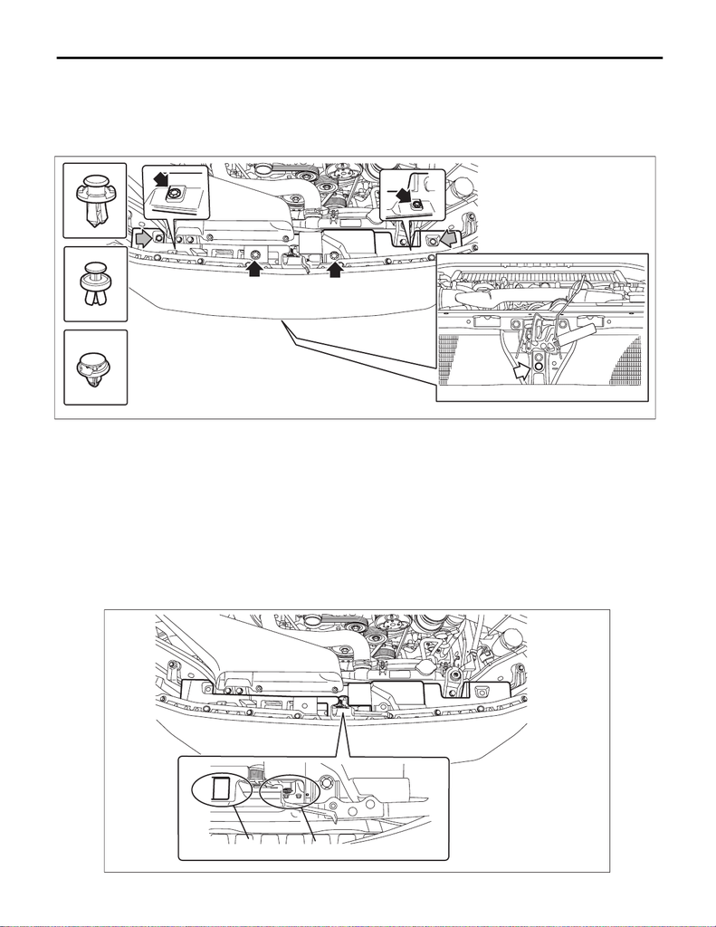

SL-54

Front Hood Lock Assembly

SECURITY AND LOCKS

C: ADJUSTMENT

1) Remove the clips at the cover UPR - front and lock assembly - front hood.

NOTE:

After adjusting the lock assembly - front hood, dispose the clips since they are no longer needed.

The clips cannot be inserted because the clip holes become smaller due to adjustment.

2) Using the ST, make adjustment by loosening the bolt at upper left through the opening (a) of the cover

UPR - front, and loosening the bolts at upper right and lower side through the opening (b).

CAUTION:

• For the bolt at upper left from the vehicle front view, use the ST.

• After adjustment, tighten the bolts securely.

NOTE:

Adjustment range of the lock assembly - front hood becomes 0±1 mm (0±0.04 in).

Preparation tool:

ST: WRENCH COMPL (499987400)

Tightening torque:

33 N·m (3.4 kgf-m, 24.3 ft-lb)

SL-02954

SL-02949

(a)

(b)

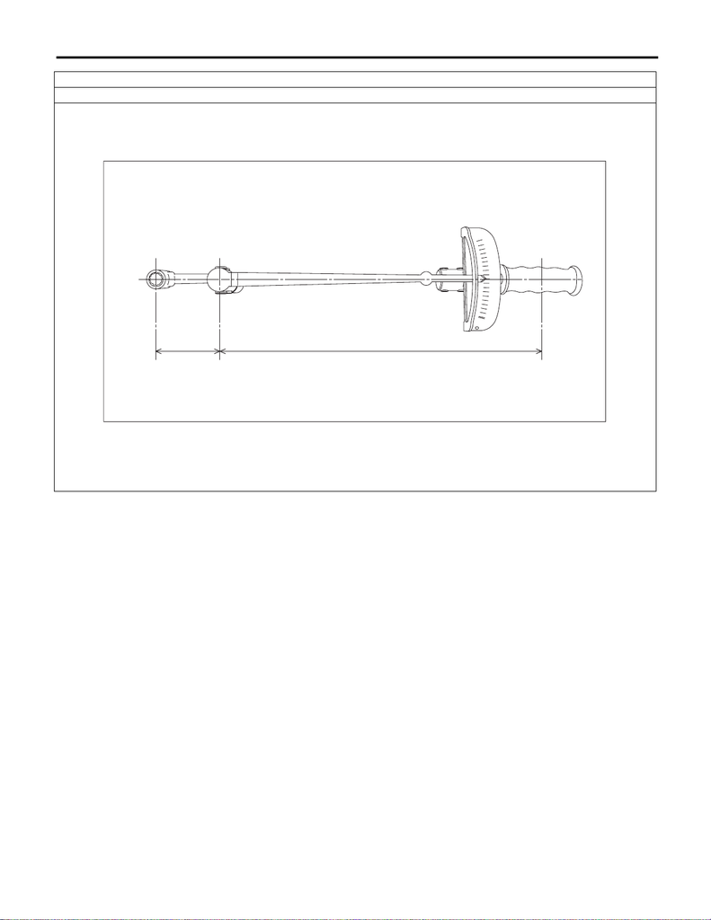

SL-55

Front Hood Lock Assembly

SECURITY AND LOCKS

D: INSPECTION

Check if the lock assembly operates normally.

If lever deformation, abnormal wear, or unsmooth lock operation is observed, replace the lock assembly -

front hood.

Calculation formula

T = L/(100 mm (3.94 in)+L) × 33 N·m (3.4 kgf-m, 24.3 ft-lb)

T: Tightening torque

L: Effective length of torque wrench

NOTE:

If the effective length of the torque wrench used is unknown, consult the manufacturer of the torque wrench.

(a) Effective length of the ST

(b) Effective length of the torque wrench

(c) Center of drive angle of the ST

(d) Center of drive angle of the torque wrench

(e) Center of the position where a force is applied by hand

SL-02955

(b)(a)

(e)(d)(c)